# DA 5030 Final Project

Jiaming Xu

Loading some packages…

```r
packages = c("webchem", "tidyverse", "rjson","rpart", "gmodels", "rminer")
package.check <- lapply(
  packages,
  function(x) {
    if (!require(x, character.only = TRUE)) {
      install.packages(x, dependencies = TRUE)
      library(x, character.only = TRUE)
    }
    else{
     library(x, character.only = TRUE)
    }
  }
)
```

The first step is collecting chemical properties of compounds we want to make prediction from PUG REST API provided by PubChem. File solubility.txt contains “compound ID”, “experimental solubility”, “ESOL predicted solubility” and “SMILEs”. Solubility.txt can only be downloaded by ftp since that’s the only download method provided by UCI ChemDB. SMILEs are used for researching through PUG REST api. In theory, compound ID should also work. There are in total 1141 compounds in this dataset.

For PUG REST api, chemical properties are converted to json format for ease. rjson package is used for retrieving data from json pages. For loop is used here for looping through all compounds. apply function can replace for loop here. Following properties are collected from json page:

[1] “cid”  
[2] “IUPAC”  
[3] “formula”  
[4] “complicity”  
[5] “hacceptor”  
[6] “hdonor”  
[7] “rotational”  
[8] “logP”  
[9] “molarmass”  
[10] “polararea”  
[11] “heavy_atom”  
[12] “atom_chiral”  
[13] “atom_chiral_def”  
[14] “atom_chiral_undef”  
[15] “bond_chiral”  
[16] “bond_chiral_def”  
[17] “bond_chiral_undef”  
[18] “isotope_atom”  
[19] “covalent_unit”  
[20] “tautomers”

```r
### Only for the first data collection ###

#df <- tibble()
names.df <- read_csv("solubility.txt")
#
#for (x in 1:nrow(names.df)) {
#  #com.name <- str_replace_all(names.df$`Compound ID`[x], " ", "%20")
#  com.smiles <- str_replace_all(names.df$SMILES[x], "#", "%23")
#  #name.url = paste0("https://pubchem.ncbi.nlm.nih.gov/rest/pug/compound/name/", #com.name, "/record/JSON")
#  smiles.url = paste0("https://pubchem.ncbi.nlm.nih.gov/rest/pug/compound/smiles/",
#         com.smiles, "/record/JSON")
#  #t <- try(fromJSON(file = name.url))
#  #if(inherits(t, "try-error")){
#  #  t <- try(fromJSON(file = smiles.url))
#  #  if(inherits(t, "try-error")){stop("Error")}
#  #  else{phy.json <- fromJSON(file = smiles.url)}
#  #}
#  #else{phy.json <- fromJSON(file = name.url)}
#
#  phy.json <- fromJSON(file = smiles.url)
#  cid <- phy.json$PC_Compounds[[1]]$id$id$cid
#  complicity <- phy.json$PC_Compounds[[1]]$props[[2]]$value$fval
#  hacceptor <- phy.json$PC_Compounds[[1]]$props[[3]]$value$ival
#  hdonor <- phy.json$PC_Compounds[[1]]$props[[4]]$value$ival
#  rotate <- phy.json$PC_Compounds[[1]]$props[[5]]$value$ival
#  IUPAC.name <- phy.json$PC_Compounds[[1]]$props[[7]]$value$sval
#  logp <- phy.json$PC_Compounds[[1]]$props[[15]]$value$fval
#  formula <- phy.json$PC_Compounds[[1]]$props[[17]]$value$sval
#  molar.mass <- phy.json$PC_Compounds[[1]]$props[[18]]$value$sval
#  polar.a <- phy.json$PC_Compounds[[1]]$props[[21]]$value$fval
#  count.prop <- phy.json$PC_Compounds[[1]]$count
#
#  m.prop <- as.list(c("cid"=cid, "IUPAC" = IUPAC.name, "formula" = formula,
#                      "complicity" = complicity, "hacceptor" = hacceptor,
#                      "hdonor" = hdonor, "rotational" = rotate, "logP" = logp,
#                      "molarmass" = molar.mass, "polararea" = polar.a))
#  df.individual <- as_tibble(c(m.prop, count.prop))
#  df <- rbind(df, df.individual)
#  if (x %% 50 == 0) {
#    print(x)
#  }
#}

MAE <- function(x,y){
  if(length(x)==length(y)){
    mean(abs(x-y))
  }
}

MSE <- function(x,y){
  if(length(x) == length(y)){
  mean((x - y)^2)
  }
}

### Save compound properties to dsv (dollar sign separated) file ###
#write_delim(df, "compound_prop.dsv", delim = "$")

### Load dataset ###
df <- read_delim("compound_prop.dsv", delim = "$")
df.all <- cbind(df, names.df[,2])
names(df.all)[21] <- "solubility"

### Accuracy of origin work
### MAE
sum(abs(names.df[,2] - names.df[,3]))/nrow(names.df)
```

```
[1] 0.6935329
```

```r
### MSE
sum((names.df[,2] - names.df[,3])**2)/nrow(names.df)
```

```
[1] 0.8209394
```

Properties:

[1] “cid” Identifier from database of chemical molecules

[2] “IUPAC” IUPAC name

[3] “formula” formula

[4] “complicity” complicity

[5] “hacceptor” Number of hydrogen bond acceptor

[6] “hdonor” Number of hydrogen bond donor

[7] “rotational” Number of rotational bond

[8] “logP” Log of P. Indicating solubility ratio of polar/non-polar

[9] “molarmass” Molar mass

[10] “polararea” Polar area

[11] “heavy_atom” Number of heavy atoms

[12] “atom_chiral” Number of chiral atom

[13] “atom_chiral_def” Number of defined chiral atom

[14] “atom_chiral_undef” Number of undefined chiral atom

[15] “bond_chiral” Number of chiral bond

[16] “bond_chiral_def” Number of defined chiral bond

[17] “bond_chiral_undef” Number of undefined chiral bond

[18] “isotope_atom” Number of isotope atoms

[19] “covalent_unit” Number of covalent

[20] “tautomers” Number of tautomers.

[21] “measured log(solubility:mol/L)”

Among those properties, atom_chiral_def, isotope_atom, and covalent_unit contain one values. Therefore drop these three columns for neat.

## Data Exploration

#### Exploring data collected.

First, let’s take a look at histogram of each variable. We can see, for most of these variables are distributed spreadly. However, frequency of atom_chiral_def and covalent_unit looks like a constant distribution. values in these two columns are the same, therefore, drop these two columns.

Therefore, categorical data not necessary for outliers detection and removal:

[13] atom_chiral_def [14] bond_chiral [15] bond_chiral_def [16] bond_chiral_undef [18] covalent_unit [5] hacceptor [6] hdonor

9 and 10 could be controversal, but I suspect these two properties have a significant impact on the solubility. Therefore, keep them.

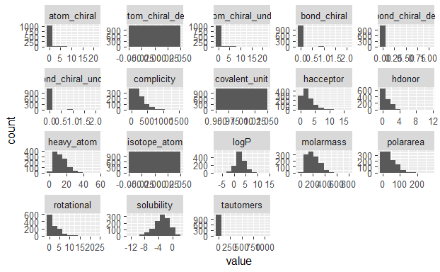

```r
ggplot(gather(df.all[,-c(1,2,3)]), aes(value)) +
  geom_histogram( bins=10) +
  facet_wrap(~key, scales = 'free')
```

```r
# Drop atom_chiral_def and covalent_unit
df_clean <- df.all %>% as_tibble() %>% select(-atom_chiral_def,-covalent_unit,
                                              -isotope_atom)
```

#### Outliers detection and removal

```r
z_cal <- function(x){
  (x-mean(x))/sd(x)
}

all_outliers_idx <- vector()

for(name in colnames(df_clean[-c(1,2,3,5,6,13,14,15,16,18)])){
  outlier_inx <- seq(nrow(df_clean))[abs(z_cal(df_clean[[name]])) > 3]
  all_outliers_idx <- append(all_outliers_idx, outlier_inx)
}

all_outliers_idx <- unique(unique(all_outliers_idx))
all_outliers_idx <- all_outliers_idx[!is.na(all_outliers_idx)]
#Remove outliers:

df_clean_no_out <- df_clean[-all_outliers_idx, ]
```

Now take another look at histogram. At this moment, distributions of all variables are reasonable for me. For example, there are fewer large molecules that people measured their solubility

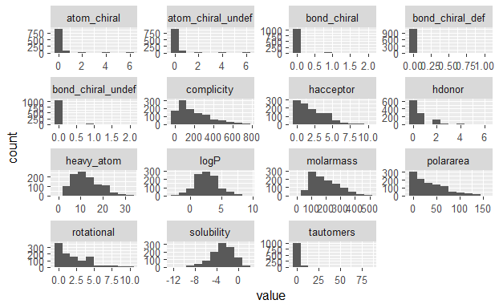

```r
ggplot(gather(df_clean_no_out[,-c(1,2,3)]), aes(value)) +
  geom_histogram( bins=10) +
  facet_wrap(~key, scales = 'free')
```

#### Correlation and data cleaning

For correlation, solubility shows a strong correlation to complicity, logP, molarmass, havy_atom. Also, it has little correlation to number of hydrogen donors.

Strong correlation:

complicity, logP, molarmass, heavy_atom.

Weak correlation:

hdonor, rotational, polararea, atom_chiral.

```r
cor(df_clean_no_out[, -c(1,2,3)], df_clean_no_out$solubility)
```

```
                          [,1]
complicity        -0.507292837
hacceptor          0.024523127
hdonor             0.233028695
rotational        -0.155823862
logP              -0.860793959
molarmass         -0.680887257
polararea          0.095030957
heavy_atom        -0.629726254
atom_chiral       -0.101392679
atom_chiral_undef -0.101392679
bond_chiral        0.002077927
bond_chiral_def    0.024408416
bond_chiral_undef -0.005739964
tautomers          0.067555751
solubility         1.000000000
```

COR of atom_chiral is the same as atom_chiral_undef. Take a deeper look for atom_chiral_undef and atom_chiral

```r
table(df_clean_no_out$atom_chiral_undef)
```

```
  0   1   2   3   4   5   6
903  97  23   8  11   9  20
```

```r
table(df_clean_no_out$atom_chiral)
```

```
  0   1   2   3   4   5   6
903  97  23   8  11   9  20
```

```r
# Test if any two values are different
sum(!(df_clean_no_out$atom_chiral_undef == df_clean_no_out$atom_chiral))
```

```
[1] 0
```

Summation is zero, means there are two identical columns. Drop one keep the other. Same strategy for bond_chiral, but there are several different values. Therefore, don’t drop bond chiral families.

```r
sum(!(df_clean_no_out$bond_chiral_undef == df_clean_no_out$bond_chiral))
```

```
[1] 3
```

```r
sum(!(df_clean_no_out$bond_chiral_def == df_clean_no_out$bond_chiral))
```

```
[1] 23
```

```r
df_clean_no_out <- df_clean_no_out %>% select( -atom_chiral_undef)
```

## Data cleaning and shaping.

#### Searching for any missing data from original work:

```r
sapply(names.df, function(x) { sum(is.na(x))})
```

```
                         Compound ID       measured log(solubility:mol/L)
                                   0                                    0
ESOL predicted log(solubility:mol/L)                               SMILES
                                   0                                    0
```

No missing data in the original data. Now let’s look at data I collected from website.

```r
glimpse(df_clean_no_out)
```

```
Rows: 1,071
Columns: 17
$ cid               <dbl> 12418, 6278, 6591, 6574, 6428, 6365, 6366, 7765, 12463, 8404, 124~
$ IUPAC             <chr> "1,1,1,2-tetrachloroethane", "1,1,1-trichloroethane", "1,1,2,2-te~
$ formula           <chr> "C2H2Cl4", "C2H3Cl3", "C2H2Cl4", "C2H3Cl3", "C2Cl3F3", "C2H4Cl2",~
$ complicity        <dbl> 35.3, 26.4, 26.5, 18.9, 90.5, 11.5, 27.0, 39.8, 102.0, 92.6, 104.~
$ hacceptor         <dbl> 0, 0, 0, 0, 3, 0, 0, 2, 0, 0, 0, 0, 0, 0, 0, 0, 0, 0, 0, 2, 0, 0,~
$ hdonor            <dbl> 0, 0, 0, 0, 0, 0, 0, 0, 0, 0, 0, 0, 0, 0, 0, 0, 0, 0, 0, 2, 0, 0,~
$ rotational        <dbl> 0, 0, 1, 1, 1, 0, 0, 4, 0, 0, 0, 0, 0, 0, 0, 0, 0, 0, 0, 0, 0, 1,~
$ logP              <dbl> 2.7, 2.4, 2.4, 1.9, 3.2, 1.9, 2.3, 0.8, 4.6, 3.5, 4.7, 4.1, 3.6, ~
$ molarmass         <dbl> 167.80, 133.40, 167.80, 133.40, 187.37, 98.96, 96.94, 118.17, 215~
$ polararea         <dbl> 0.0, 0.0, 0.0, 0.0, 0.0, 0.0, 0.0, 18.5, 0.0, 0.0, 0.0, 0.0, 0.0,~
$ heavy_atom        <dbl> 6, 5, 6, 5, 8, 4, 4, 8, 10, 10, 10, 9, 9, 10, 10, 10, 9, 9, 9, 8,~
$ atom_chiral       <dbl> 0, 0, 0, 0, 0, 0, 0, 0, 0, 0, 0, 0, 0, 0, 0, 0, 0, 0, 0, 0, 0, 0,~
$ bond_chiral       <dbl> 0, 0, 0, 0, 0, 0, 0, 0, 0, 0, 0, 0, 0, 0, 0, 0, 0, 0, 0, 0, 0, 0,~
$ bond_chiral_def   <dbl> 0, 0, 0, 0, 0, 0, 0, 0, 0, 0, 0, 0, 0, 0, 0, 0, 0, 0, 0, 0, 0, 0,~
$ bond_chiral_undef <dbl> 0, 0, 0, 0, 0, 0, 0, 0, 0, 0, 0, 0, 0, 0, 0, 0, 0, 0, 0, 0, 0, 0,~
$ tautomers         <dbl> 1, 1, 1, 1, 2, 1, 1, 1, -1, 1, 1, -1, 1, -1, 1, -1, 1, 1, 1, -1, ~
$ solubility        <dbl> -2.18, -2.00, -1.74, -1.48, -3.04, -1.29, -1.64, -0.43, -4.57, -4~
```

Searching for missing values:

```r
sapply(df_clean_no_out, function(x) sum(is.na(x)))
```

```
              cid             IUPAC           formula        complicity         hacceptor
                0                 0                 0                 0                 0
           hdonor        rotational              logP         molarmass         polararea
                0                 0                 0                 0                 0
       heavy_atom       atom_chiral       bond_chiral   bond_chiral_def bond_chiral_undef
                0                 0                 0                 0                 0
        tautomers        solubility
                0                 0
```

There are also no missing value for data I collected. Now, randomly drop 5% data as missing data.

```r
set.seed(7)
missing_idx <- sample(1:nrow(df_clean_no_out), 0.05*nrow(df_clean_no_out))
df_clean_no_out <- df_clean_no_out[-missing_idx, ] %>% as_tibble()
```

## Model Construction & Evaluation

### - Hold-out method

```r
set.seed(0)
train.sample.idx <- sample(1:nrow(df_clean_no_out), 0.7*nrow(df_clean_no_out))
train.sample <- df_clean_no_out[train.sample.idx, -c(1,2,3)] %>% as.data.frame()
test.sample <- df_clean_no_out[-train.sample.idx, -c(1,2,3)] %>% as.data.frame()
```

### Model tree: rpart

```r
library(rpart)
library(gmodels)
model.tree.reg <- rpart(solubility ~ complicity + hacceptor + hdonor + rotational + logP +
    molarmass + polararea + heavy_atom + atom_chiral + bond_chiral +
    bond_chiral_def + tautomers, data = train.sample)
model.tree.pred <- predict(model.tree.reg, test.sample)
###  MAE:
MAE(model.tree.pred, test.sample$solubility)
```

```
[1] 0.692779
```

```r
MSE(model.tree.pred, test.sample$solubility)
```

```
[1] 0.7767101
```

### Multi-Linear regression: lm

```r
lm_step_back <- step(lm(solubility ~ ., data = train.sample), direction = 'backward',   trace = 1)
```

```
Start:  AIC=-348.6
solubility ~ complicity + hacceptor + hdonor + rotational + logP +
    molarmass + polararea + heavy_atom + atom_chiral + bond_chiral +
    bond_chiral_def + bond_chiral_undef + tautomers


Step:  AIC=-348.6
solubility ~ complicity + hacceptor + hdonor + rotational + logP +
    molarmass + polararea + heavy_atom + atom_chiral + bond_chiral +
    bond_chiral_def + tautomers

                  Df Sum of Sq    RSS     AIC
- atom_chiral      1      0.86 421.58 -349.14
<none>                         420.71 -348.60
- bond_chiral_def  1      1.39 422.11 -348.25
- molarmass        1      1.57 422.28 -347.95
- tautomers        1      1.77 422.48 -347.61
- bond_chiral      1      1.79 422.51 -347.57
- hdonor           1      2.38 423.10 -346.58
- heavy_atom       1      2.73 423.44 -346.00
- complicity       1      4.39 425.10 -343.21
- hacceptor        1     12.76 433.47 -329.33
- polararea        1     15.25 435.96 -325.25
- rotational       1     21.05 441.76 -315.84
- logP             1    435.41 856.12  155.25

Step:  AIC=-349.14
solubility ~ complicity + hacceptor + hdonor + rotational + logP +
    molarmass + polararea + heavy_atom + bond_chiral + bond_chiral_def +
    tautomers

                  Df Sum of Sq    RSS     AIC
<none>                         421.58 -349.14
- bond_chiral_def  1      1.37 422.94 -348.84
- molarmass        1      1.38 422.96 -348.82
- bond_chiral      1      1.61 423.19 -348.42
- hdonor           1      1.79 423.36 -348.13
- tautomers        1      1.99 423.57 -347.78
- heavy_atom       1      3.54 425.11 -345.19
- complicity       1      3.57 425.14 -345.14
- hacceptor        1     13.19 434.77 -329.20
- polararea        1     18.96 440.54 -319.82
- rotational       1     23.92 445.50 -311.85
- logP             1    447.39 868.96  163.85
```

```r
lm.pred <- predict(lm_step_back, newdata = test.sample)
MAE(lm.pred, test.sample$solubility)
```

```
[1] 0.5782866
```

```r
MSE(lm.pred, test.sample$solubility)
```

```
[1] 0.6046826
```

```r
#CrossTable(predict(lm_step_back, newdata = test.sample),test.sample$solubility)
```

### ANN - Using neuralnet/ANN2/rminer package.

I used neuralnet for ANN at the beginning, however, it ran really really slow. It took 20 mins for creating a 4 nodes ANN. Therefore, I tried ANN2. It complied much faster however the accuracy is whole of a mass. After that, I searched online and found a review paper of performance ANN packages in r. available here:

https://www.inmodelia.com/exemples/2021-0103-RJournal-SM-AV-CD-PK-JN.pdf

nlsr, rminer, nnet are three top accurate packages with the compiling speed in a reversed order. Therefore, I chose rminer as ANN calculation package. The rminer package is a basket containing many algorithms. For example, nnet package is used as ann algorithm in rminer. The nnet is a feed-forward neural networks with a single hidden layer. Therefore, more than one layer is not supported.

```r
set.seed(0)
nn <- fit(solubility ~., train.sample, model='mlpe',size= 5 ,decay=0.1,maxit=500,rang=0.9)
nn.pred <- predict(nn, test.sample)
MAE(nn.pred, test.sample$solubility)
```

```
[1] 0.4618904
```

```r
MSE(nn.pred, test.sample$solubility)
```

```
[1] 0.3852565
```

What if we use strong correlated chemical properties?

```r
set.seed(0)
nn <- fit(solubility ~ complicity +logP + molarmass + heavy_atom,
          train.sample, model='mlp',size= 5 ,decay=0.1,maxit=500)
nn.pred <- predict(nn, test.sample)
MAE(nn.pred, test.sample$solubility)
```

```
[1] 0.5385587
```

```r
MSE(nn.pred, test.sample$solubility)
```

```
[1] 0.4758679
```

We see that the performance of ANN using 4 strong correlated properties is worse than using all parameters. Which means, other weak correlated parameters also affect accuracy.

#### ANN with default best network.

Now, we see that both MAE and MSE increased.

```r
set.seed(0)
nn <- fit(solubility ~., train.sample, model='mlpe', maxit=540)
nn.pred <- predict(nn, test.sample)
MAE(nn.pred, test.sample$solubility)
```

```
[1] 0.4944736
```

```r
MSE(nn.pred, test.sample$solubility)
```

```
[1] 0.4269923
```

```r
set.seed(0)
nn <- fit(solubility ~ ., train.sample, model='mlp')
nn.pred <- predict(nn, test.sample)
MAE(nn.pred, test.sample$solubility)
```

```
[1] 0.4603303
```

```r
MSE(nn.pred, test.sample$solubility)
```

```
[1] 0.3832255
```

### Model Tree

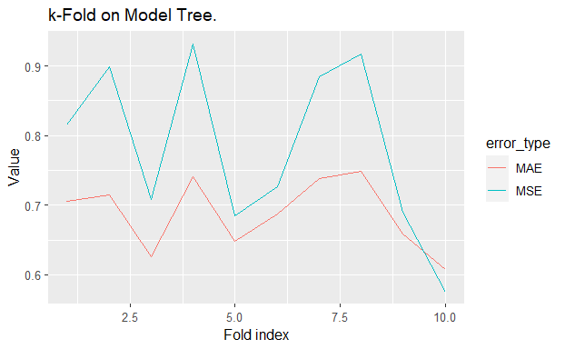

```r
set.seed(0)
k = 10
kfold.result <- tibble("Fold" = numeric(), MAE = numeric(), MSE = numeric(),
                       "Resample" = character())
k_groups <- sample(1:10, size=nrow(df_clean_no_out), replace=TRUE, prob=rep(.1,10))
for(i in 1:k){
  train.sample.idx <- seq(1,nrow(df_clean_no_out))[ k_groups != i]
  train.sample <- df_clean_no_out[train.sample.idx, -c(1,2,3)] %>% as.data.frame()
  test.sample <- df_clean_no_out[-train.sample.idx, -c(1,2,3)] %>% as.data.frame()

  model.tree.reg <- rpart(solubility ~ complicity + hacceptor + hdonor + rotational + logP +
      molarmass + polararea + heavy_atom + atom_chiral + bond_chiral +
      bond_chiral_def + tautomers, data = train.sample)
  model.tree.pred <- predict(model.tree.reg, test.sample)
  maei = MAE(model.tree.pred, test.sample$solubility)
  msei = MSE(model.tree.pred, test.sample$solubility)


  kfold.result <- add_row(kfold.result, Fold = i, Resample = paste0("fold",i),
                          MAE = maei, MSE = msei)
}

kfold.result %>%
  pivot_longer( cols = c(MAE, MSE), values_to = 'value', names_to = 'error_type') %>%
  ggplot() +
  geom_line( mapping = aes( x = Fold, y = value, color = error_type)) +
  labs( x = "Fold index", y = "Value", title = "k-Fold on Model Tree.")
```

Mean k-fold error:

```r
sapply(kfold.result[c(2,3)], mean)
```

```
      MAE       MSE
0.6876257 0.7831584
```

### Linear Regression

```r
set.seed(0)
k = 10
kfold.result <- tibble("Fold" = numeric(), MAE = numeric(), MSE = numeric(),
                       "Resample" = character())
k_groups <- sample(1:10, size=nrow(df_clean_no_out), replace=TRUE, prob=rep(.1,10))
for(i in 1:k){
  train.sample.idx <- seq(1,nrow(df_clean_no_out))[ k_groups != i]
  train.sample <- df_clean_no_out[train.sample.idx, -c(1,2,3)] %>% as.data.frame()
  test.sample <- df_clean_no_out[-train.sample.idx, -c(1,2,3)] %>% as.data.frame()

  lm_step_back <- step(lm(solubility ~ ., data = train.sample),
                       direction = 'backward',   trace = 0)
  lm.pred <- predict(lm_step_back, newdata = test.sample)
  maei = MAE(lm.pred, test.sample$solubility)
  msei = MSE(lm.pred, test.sample$solubility)


  kfold.result <- add_row(kfold.result, Fold = i, Resample = paste0("fold",i),
                          MAE = maei, MSE = msei)
}

kfold.result %>%
  pivot_longer( cols = c(MAE, MSE), values_to = 'value', names_to = 'error_type') %>%
  ggplot() +
  geom_line( mapping = aes( x = Fold, y = value, color = error_type)) +
  labs( x = "Fold index", y = "Value", title = "k-Fold on Linear Regression.")
```

[output not shown]

Mean k-fold error:

```r
sapply(kfold.result[c(2,3)], mean)
```

[output not shown]

### ANN

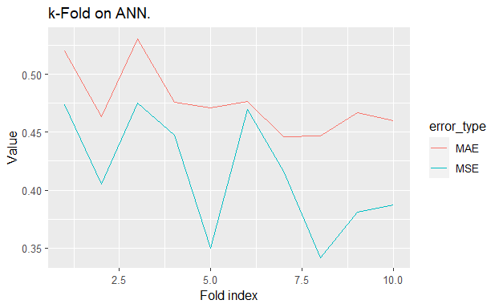

```r
set.seed(0)
k = 10
kfold.result <- tibble("Fold" = numeric(), MAE = numeric(), MSE = numeric(),
                       "Resample" = character())
k_groups <- sample(1:10, size=nrow(df_clean_no_out), replace=TRUE, prob=rep(.1,10))
for(i in 1:k){
  train.sample.idx <- seq(1,nrow(df_clean_no_out))[ k_groups != i]
  train.sample <- df_clean_no_out[train.sample.idx, -c(1,2,3)] %>% as.data.frame()
  test.sample <- df_clean_no_out[-train.sample.idx, -c(1,2,3)] %>% as.data.frame()

  nn <- fit(solubility ~ ., train.sample, model='mlp')
  nn.pred <- predict(nn, test.sample)
  maei <- MAE(nn.pred, test.sample$solubility)
  msei <- MSE(nn.pred, test.sample$solubility)


  kfold.result <- add_row(kfold.result, Fold = i, Resample = paste0("fold",i),
                          MAE = maei, MSE = msei)
}

kfold.result %>%
  pivot_longer( cols = c(MAE, MSE), values_to = 'value', names_to = 'error_type') %>%
  ggplot() +
  geom_line( mapping = aes( x = Fold, y = value, color = error_type)) +
  labs( x = "Fold index", y = "Value", title = "k-Fold on ANN.")
```

Mean k-fold error:

```r
sapply(kfold.result[c(2,3)], mean)
```

```
      MAE       MSE
0.4757869 0.4147867
```

### Tuning hyperparameter of nnet.

```r
set.seed(0)
ann.hyper.tune <- tibble("nnode"=numeric(), "mae" = numeric(), "mse" = numeric())
for(i in 1:25){
  nn <- fit(solubility ~ ., train.sample, model='mlpe', size = i, decay = 0.1, maxit = 500)
  nn.predict <- predict(nn, test.sample)
  ann.hyper.tune <- add_row(ann.hyper.tune, nnode = i, mae = MAE(nn.predict, test.sample$solubility),           mse = MSE(nn.predict, test.sample$solubility))
}
```

#### Plotting MAE and MSE of ANN as a function of number of nodes.

```r
ann.hyper.tune %>%
  pivot_longer(cols = c(mae,mse), names_to = 'error_type', values_to = 'value') %>%
  ggplot() +
  geom_line( mapping = aes( x = nnode, y = value, color = error_type)) +
  labs( x = "number of nodes", y = "error value", title = "MAE and MSE of ANN with different number of nodes.")
```

[output not shown]

Therefore, we use method =‘mlpe’ with 14 nodes as our best ANN model created:

```r
set.seed(0)
nn.best <- fit(solubility ~ ., train.sample, model='mlpe', size = 14, decay = 0.1, maxit = 500)
nn.pred <- predict(nn, test.sample)
MAE(nn.pred, test.sample$solubility)
MSE(nn.pred, test.sample$solubility)
```

[output not shown]